# Homework 3

## Report

**Please click between the tabs above to toggle between the report and appendix.**

### Exploratory Data Analysis

Not all variables in the data are numeric, and the cylidners variable has a very limited range of numbers which is not suitable for a density plot. Below we see the distribution of some of the key numeric variables.

Each of these variables are skewed to the right. They appear to form a distribution very similar to some form of an f-distribution. This will make linear predictions more difficult for these variables.

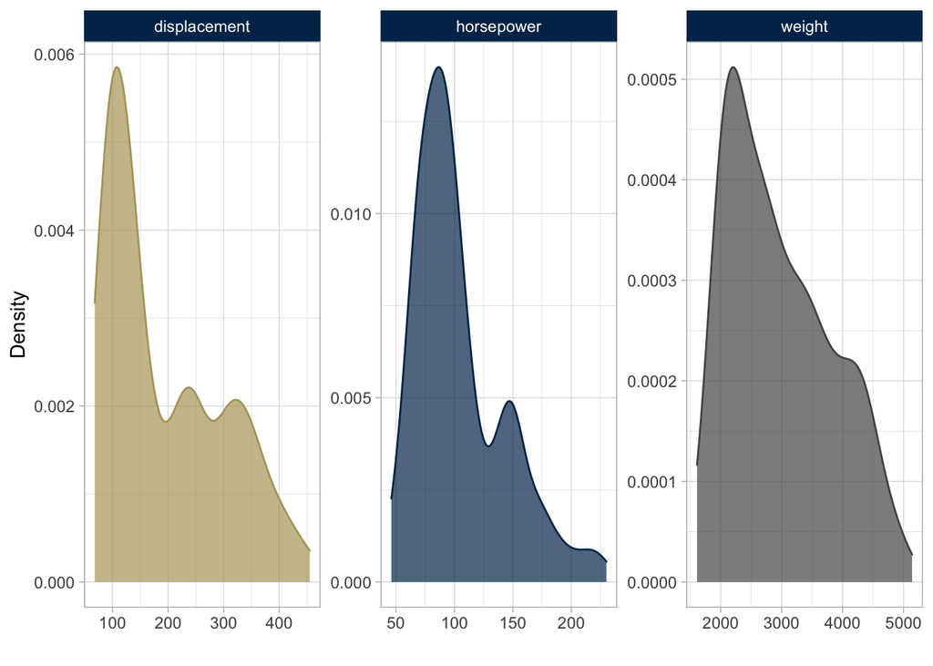

It certainly appears that vehicles with a higher horsepower lead to more below-median miles per gallon.

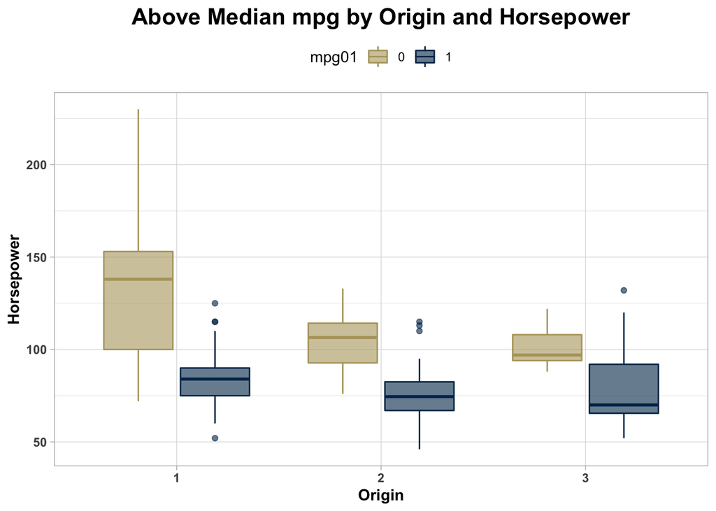

Intuitively the weight of a car will have an impact on its fuel efficiency as the more weight that must be moved requires more energy. Here’s an area plot to show that heavier cars tend to be less fuel efficient.

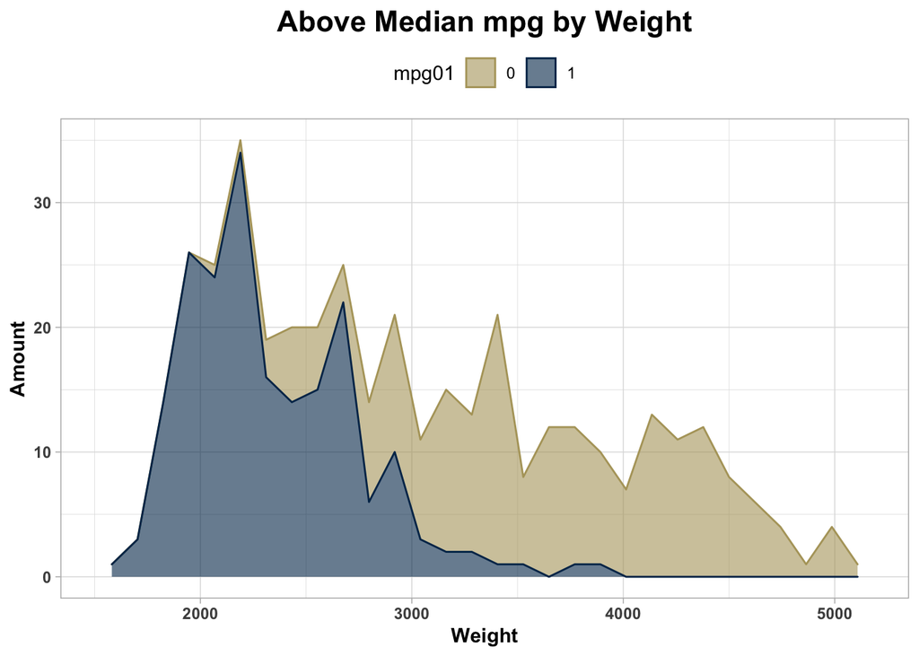

Now we see some very strong clustering structure, mostly provided by the displacement variable. As displacement increases it becomes much easier to differentiate between above-median and below-median fuel efficiency.

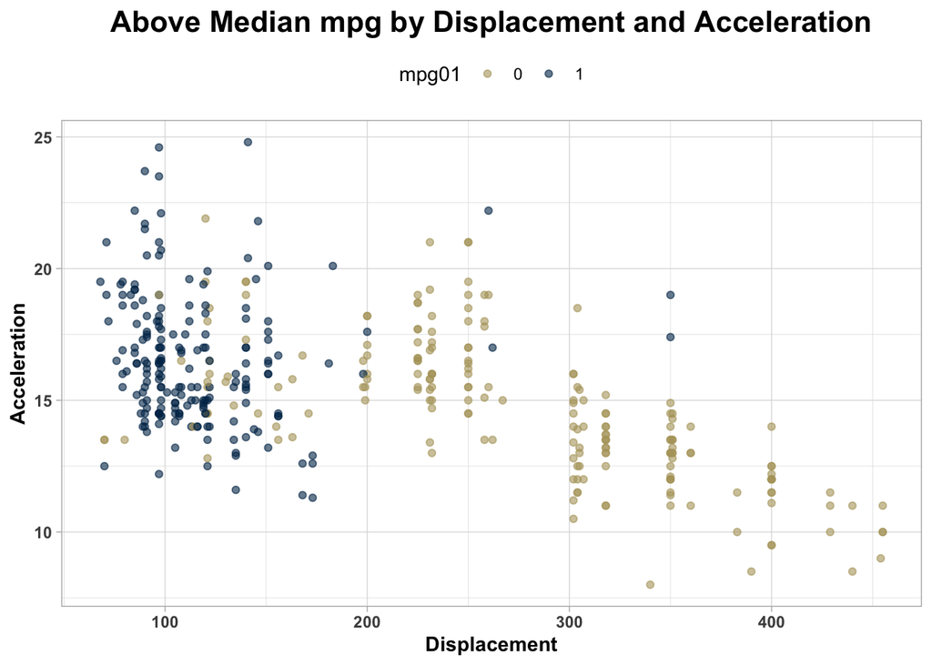

When you combine the clearly impactful weight and horsepower variables the picture is very clear. Higher horsepower and higher weight are exclusively below-median in our dataset.

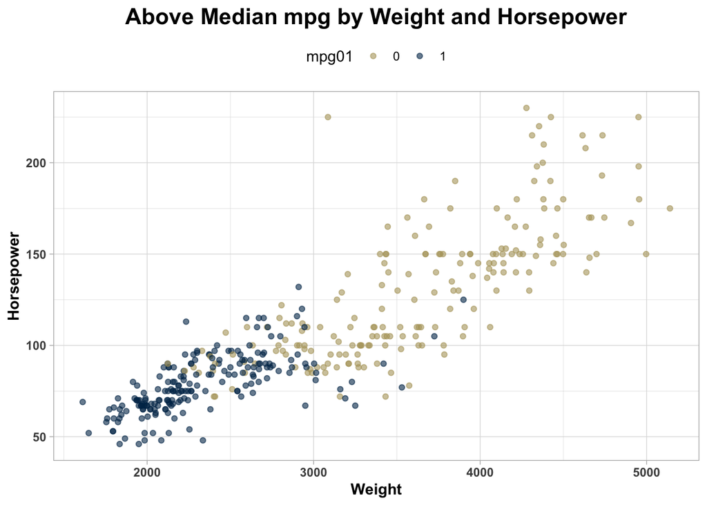

### Methods

To properly analyze this data I split it into a conventional 80-20 split between training and testing sets. The only variable that was removed for this analysis was the year the car was made as it did not show much of an effect on mpg. I’ll outline each of the methods used to predict mpg01 below. The caret and MASS packages were used for the implementations of these algorithms. Each of the models below outline their respective process. The code for each can be found in the appendix.

#### Linear Discriminant

I used the MASS function lda() to compute the linear discriminant. Prior to computing the model the data was scaled to ensure the algorithm wouldn’t be misled by variables of different scale. The origin variable was not scaled as I considered it a categorical variable. Below you’ll find the summary of the model.

```
## Call:
## lda(mpg01 ~ ., data = train.transformed)
##
## Prior probabilities of groups:
##   0   1
## 0.5 0.5
##
## Group means:
##   cylinders displacement horsepower     weight acceleration    origin2
## 0  0.768109    0.7600549  0.6663363  0.7569756   -0.3715468 0.06369427
## 1 -0.768109   -0.7600549 -0.6663363 -0.7569756    0.3715468 0.28662420
##      origin3
## 0 0.03821656
## 1 0.33757962
##
## Coefficients of linear discriminants:
##                       LD1
## cylinders    -0.902782685
## displacement -0.001608762
## horsepower    0.161417568
## weight       -0.736327966
## acceleration  0.062698488
## origin2       0.341295275
## origin3       0.484632157
```

#### Quadratic Discriminant

The quadratic discriminant was also trained on the scaled data use the MASS library’s qda() function. The main difference between the LDA and QDA is that QDA does not assume equality of variance/covariance. This makes QDA more flexible to each grouping, which tends to have a more substantive impact on larger training datasets.

```
## Call:
## qda(mpg01 ~ ., data = train.transformed)
##
## Prior probabilities of groups:
##   0   1
## 0.5 0.5
##
## Group means:
##   cylinders displacement horsepower     weight acceleration    origin2
## 0  0.768109    0.7600549  0.6663363  0.7569756   -0.3715468 0.06369427
## 1 -0.768109   -0.7600549 -0.6663363 -0.7569756    0.3715468 0.28662420
##      origin3
## 0 0.03821656
## 1 0.33757962
```

#### Naive Bayes

The Naive Bayes Classifier is founded on the idea of Bayesian Probaility: $P(A \mid B) = P(A)(P(B \mid A)) / P(B)$. The greatest flaw here is that it assumes the predictors are conditionally independent. Therefore, correlation between variables is not accounted for in the model. In my implementation I ran a 5-fold cross-validation using the caret package’s trainControl() function.

Below you can see a confusion matrix of the cross-validated training:

```
## Cross-Validated (5 fold) Confusion Matrix
##
## (entries are percentual average cell counts across resamples)
##
##           Reference
## Prediction    0    1
##          0 44.3  3.5
##          1  5.7 46.5
##
##  Accuracy (average) : 0.9076
```

#### Logistic Regression

The Logisitc Regression was implemented simply using base R’s glm() function with the family = ‘binomial’. In order to guage the goodness of fit for the model we can look at McFadden’s pseudo-$R^{2}$. This model’s $R^{2}_{pseudo}$ = 0.627. The summary of each of the model’s coefficients is below:

```
##
## Call:
## glm(formula = mpg01 ~ ., family = "binomial", data = train.data)
##
## Deviance Residuals:
##     Min       1Q   Median       3Q      Max
## -2.3110  -0.1724   0.0424   0.3427   3.3262
##
## Coefficients:
##               Estimate Std. Error z value Pr(>|z|)
## (Intercept)  10.572691   3.041401   3.476 0.000508 ***
## cylinders    -0.070744   0.401599  -0.176 0.860173
## displacement -0.012494   0.011375  -1.098 0.272021
## horsepower   -0.038186   0.022516  -1.696 0.089902 .
## weight       -0.001849   0.001077  -1.717 0.085988 .
## acceleration  0.047246   0.144115   0.328 0.743035
## origin2       0.088231   0.648210   0.136 0.891731
## origin3       0.486780   0.704219   0.691 0.489418
## ---
## Signif. codes:  0 '***' 0.001 '**' 0.01 '*' 0.05 '.' 0.1 ' ' 1
##
## (Dispersion parameter for binomial family taken to be 1)
##
##     Null deviance: 435.30  on 313  degrees of freedom
## Residual deviance: 162.57  on 306  degrees of freedom
## AIC: 178.57
##
## Number of Fisher Scoring iterations: 7
```

Interestingly, logistic regression only deems horsepower and weight as “significant” below the .1 p-value level. These values are above the standard .05 level.

#### Support Vector Machine

The SVM was built using the svmRadial method (non-linear) using the caret pacakge. This model was also cross validated and scaled.

### Results

Here’s a table with the accuracy of each model (the calculation for each is in the appendix):

[output not shown]

To visualize the differences of each model, here are two of the most important variables plotted with the model’s correct and incorrect predictions.

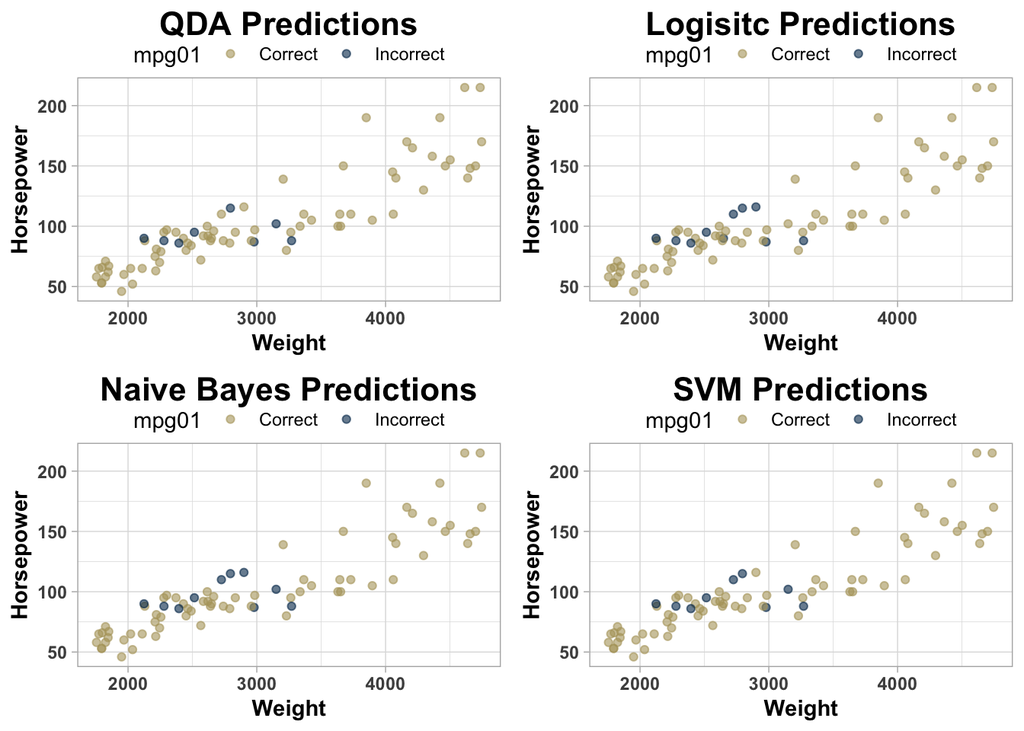

### Findings

[figure not shown]

## Appendix

```r
library(caret)
dat <- subset(dat, select = -c(year))
training.samples <- dat$mpg01 %>%
  createDataPartition(p = 0.8, list = FALSE)

dat$origin <- as.factor(dat$origin)
dat$mpg01 <- as.factor(dat$mpg01)

train.data <- dat[training.samples, ]
test.data <- dat[-training.samples, ]

# this method automatically ignores factor/character vars
# while considering the scale of the training data
preproc.param <- train.data %>%
  preProcess(method = c("center", "scale"))

train.transformed <- preproc.param %>% predict(train.data)
test.transformed <- preproc.param %>% predict(test.data)

library(MASS)
# Fit the model
lda_model <- lda(mpg01~., data = train.transformed)
# Make predictions
lda_predictions <- lda_model %>% predict(test.transformed)
lda_model
```

```r
qda_model <- qda(mpg01~., data = train.transformed)
qda_predictions <- qda_model %>% predict(test.transformed)
qda_model
```

```r
# set up 5-fold cross validation procedure
train_control <- trainControl(
  method = "cv",
  number = 5
  )

# train model w/ 5 cv folds
n_bayes <- train(
  x = subset(train.data, select = -c(mpg01)),
  y = train.data$mpg01,
  method = "nb",
  trControl = train_control
  )
nb_pred <- predict(n_bayes, newdata = test.data)
caret::confusionMatrix(n_bayes)
```

```r
log_model <- glm(mpg01 ~., data = train.data, family = 'binomial')
log_preds <- predict(log_model, test.data, type = 'response')
```

```r
num_k <- c(1,3,5,7,9)
run_knn_test <- function(num_neighbors, train, test){
  model <- train(
    mpg01 ~., data = train, method = "knn",
    trControl = trainControl("cv", number = 5),
    preProcess = c("center","scale"),
    tuneLength = 20
  )

  knn_preds <- predict(model, test)
  accuracy <- mean(knn_preds == test$mpg01)
  return(accuracy)
}
```

```r
svm_train <- train.data %>% dplyr::select(weight, horsepower, mpg01)
svm_model <- train(
  mpg01 ~., data = train.data, method = "svmRadial",
  trControl = trainControl("cv", number = 5),
  preProcess = c("center","scale"),
  tuneLength = 10
  )
svm_preds <- predict(svm_model, test.data)
```

```r
lda_error <- mean(lda_predictions$class==test.transformed$mpg01)
qda_error <- mean(qda_predictions$class == test.transformed$mpg01)
nb_error <- mean(nb_pred == test.data$mpg01)
logistic_error <- mean(round(log_preds) == test.data$mpg01)
knn_error <- purrr::map(num_k, run_knn_test, train = train.data, test = test.data)
svm_error <- mean(svm_preds == test.data$mpg01)
```

[figure not shown]